# Lupercio_Daniel_HW5

## Daniel Lupercio - STAT 724 HW5

```python
# %load ../standard_import.txt
import pandas as pd
import numpy as np
import matplotlib as mpl
import matplotlib.pyplot as plt
import seaborn as sns

from sklearn.preprocessing import scale,StandardScaler
from sklearn.decomposition import PCA
from sklearn.cluster import KMeans
from sklearn.metrics import confusion_matrix,accuracy_score

from scipy.cluster import hierarchy
from scipy.cluster.hierarchy import dendrogram, linkage
from sklearn.cluster import AgglomerativeClustering

%matplotlib inline
plt.style.use('seaborn-white')
```

## 10. In this problem, you will generate simulated data, and then perform PCA and K-means clustering on the data.

### Generate a simulated data set with 20 observations in each of three classes (i.e. 60 observations total), and 50 variables. Be sure to add a mean shift to the observations in each class so that there are three distinct classes.

```python
np.random.seed(0)
c1 = np.append(np.random.normal(0, .1, (20, 49)), np.full((20, 1), 1), axis=1)
c2 = np.append(np.random.normal(0.1, .1, (20, 49)), np.full((20, 1), 2), axis=1)
c3 = np.append(np.random.normal(-0.1, .1, (20, 49)), np.full((20, 1), 3), axis=1)

df = pd.DataFrame(np.vstack((c1,c2,c3)))
```

```python
df.shape
```

```
(60, 50)
```

### (b) Perform PCA on the 60 observations and plot the first two principal component score vectors. Use a different color to indicate the observations in each of the three classes. If the three classes appear separated in this plot, then continue on to part (c). If not, then return to part (a) and modify the simulation so that there is greater separation between the three classes. Do not continue to part (c) until the three classes show at least some separation in the first two principal component score vectors.

```python
pca = PCA(n_components=2)
principalComponents = pca.fit_transform(df.iloc[:,0:49])
df_pca = pd.DataFrame(principalComponents, columns=['PC1', 'PC2'])
df_pca['labels'] = df[[49]]
df_pca.labels = df_pca.labels.astype(int)
```

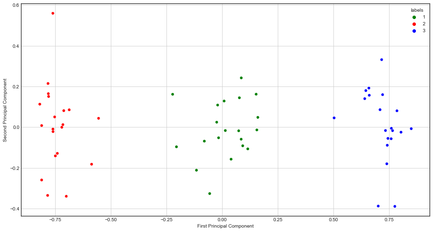

```python
fig = plt.figure(figsize=(15, 8))
sns.scatterplot(x="PC1", y="PC2", hue="labels", palette={1:'green', 2:'red', 3:'blue'}, data=df_pca)
plt.grid()
plt.xlabel("First Principal Component")
plt.ylabel("Second Principal Component")
plt.show()
```

### (c) Perform K-means clustering of the observations with K = 3. How well do the clusters that you obtained in K-means clustering compare to the true class labels? Be careful how you interpret the results: K-means clustering will arbitrarily number the clusters, so you cannot simply check whether the true class labels and clustering labels are the same.

```python
km3 = KMeans(n_clusters=3, n_init=5, random_state=0)
km3.fit(df)
```

```
KMeans(n_clusters=3, n_init=5, random_state=0)
```

```python
y_pred = km3.fit_predict(df)
print(y_pred)
```

```
[2 2 2 2 2 2 2 2 2 2 2 2 2 2 2 2 2 2 2 2 1 1 1 1 1 1 1 1 1 1 1 1 1 1 1 1 1
 1 1 1 0 0 0 0 0 0 0 0 0 0 0 0 0 0 0 0 0 0 0 0]
```

```python
km3_labels = (km3.labels_)
print(km3_labels)
```

```
[2 2 2 2 2 2 2 2 2 2 2 2 2 2 2 2 2 2 2 2 1 1 1 1 1 1 1 1 1 1 1 1 1 1 1 1 1
 1 1 1 0 0 0 0 0 0 0 0 0 0 0 0 0 0 0 0 0 0 0 0]
```

```python
#Print a matrix, with class and true lables on the top and bottom
```

```python
pd.Series(km3.labels_).value_counts()
```

```
0    20
1    20
2    20
dtype: int64
```

```python
cm = confusion_matrix(y_pred, km3_labels)
print("Confusion Matrix: \n", cm)
# cm_argmax = cm.argmax(axis=0)
# print(cm_argmax)
# y_pred_ = np.array([cm_argmax[i] for i in y_pred])
print("Accuracy Score: ", accuracy_score(km3_labels,y_pred_))
```

[output not shown]

The confusion matrix leads me to infer that the class labels are correctly classified.

### (d) Perform K-means clustering of the observations with K = 2. How well do the clusters that you obtained in K-means clustering compare to the true class labels?

```python
km2 = KMeans(n_clusters=2, n_init=5, random_state=0)
km2.fit(df.iloc[:,:49])
```

```
KMeans(n_clusters=2, n_init=5, random_state=0)
```

```python
km2_labels = (km2.labels_)
print(km2_labels)
```

```
[1 1 0 1 1 1 1 1 1 1 1 1 1 1 1 1 1 1 1 0 0 0 0 0 0 0 0 0 0 0 0 0 0 0 0 0 0
 0 0 0 1 1 1 1 1 1 1 1 1 1 1 1 1 1 1 1 1 1 1 1]
```

```python
y2_pred = km2.fit_predict(df)
```

```python
cm2 = confusion_matrix(y2_pred, km2_labels)
print("Confusion matrix : \n", cm2)
cm2_argmax = cm2.argmax(axis=0)
print(cm2_argmax)
```

```
Confusion matrix :
 [[ 0 20]
 [22 18]]
[1 0]
```

```python
# y2_pred_ = np.array([cm2_argmax[i] for i in y2_pred])
# cm2_ = confusion_matrix(y2_pred, km3_labels)
# print(cm2_)
print(accuracy_score(km2_labels,y2_pred))
```

```
0.3
```

```python
pd.Series(km2.labels_).value_counts()
```

[output not shown]

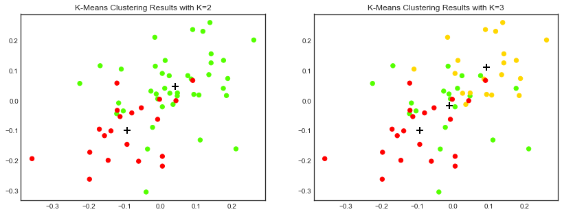

```python
fig, (ax1, ax2) = plt.subplots(1,2, figsize=(14,5))

ax1.scatter(df.iloc[:,0], df.iloc[:,1], s=40, c=km2.labels_, cmap=plt.cm.prism)
ax1.set_title('K-Means Clustering Results with K=2')
ax1.scatter(km2.cluster_centers_[:,0], km2.cluster_centers_[:,1], marker='+', s=100, c='k', linewidth=2)

ax2.scatter(df.iloc[:,0], df.iloc[:,1], s=40, c=km3.labels_, cmap=plt.cm.prism)
ax2.set_title('K-Means Clustering Results with K=3')
ax2.scatter(km3.cluster_centers_[:,0], km3.cluster_centers_[:,1], marker='+', s=100, c='k', linewidth=2);
```

### (e) Now perform K-means clustering with K = 4, and describe your results.

```python
km4 = KMeans(n_clusters=4, n_init=50, random_state=0)
km4.fit(df.iloc[:,:49])
```

```
KMeans(n_clusters=4, n_init=50, random_state=0)
```

```python
print(km4.labels_)
```

```
[0 3 3 0 0 3 3 3 0 3 0 0 3 3 0 3 3 0 0 3 1 1 1 1 1 1 1 1 1 1 1 1 1 1 1 1 1
 1 1 1 2 2 2 2 2 2 2 2 2 2 2 2 2 2 2 2 2 2 2 2]
```

```python
# Observations per KMeans cluster
pd.Series(km4.labels_).value_counts()
```

```
1    20
2    20
3    11
0     9
dtype: int64
```

### (f) Now perform K-means clustering with K = 3 on the first two principal component score vectors, rather than on the raw data. That is, perform K-means clustering on the 60 × 2 matrix of which the first column is the first principal component score vector, and the second column is the second principal component score vector. Comment on the results.

```python
pca_f = PCA(n_components=3)
principalComponents = pca_f.fit_transform(df.iloc[:,0:49])
df_pca_f = pd.DataFrame(principalComponents, columns=['PC1', 'PC2', 'PC3'])
```

```python
df_pca_f = df_pca_f.iloc[:,0:2]
print(df_pca_f.head())
```

```
        PC1       PC2
0 -0.114929 -0.211609
1  0.009307  0.128210
2 -0.221930  0.161381
3  0.153161  0.161741
4 -0.023953  0.024275
```

```python
kmf = KMeans(n_clusters=3, n_init=50, random_state=0)
kmf.fit(df_pca_f)
kmf_labels = (kmf.labels_)
print(kmf_labels)
```

```
[2 2 2 2 2 2 2 2 2 2 2 2 2 2 2 2 2 2 2 2 1 1 1 1 1 1 1 1 1 1 1 1 1 1 1 1 1
 1 1 1 0 0 0 0 0 0 0 0 0 0 0 0 0 0 0 0 0 0 0 0]
```

```python
y_f = kmf.fit_predict(df_pca_f)
```

```python
print("Confusion matrix: \n", confusion_matrix(y_f,kmf_labels))
```

```
Confusion matrix:
 [[20  0  0]
 [ 0 20  0]
 [ 0  0 20]]
```

```python
pd.Series(kmf.labels_).value_counts()
```

```
0    20
1    20
2    20
dtype: int64
```

It appears the labels are matched perfectly, based on the value counts. The two principal components were able to reduce dimensional space without loss of information.

### (g) Using the scale() function, perform K-means clustering with K = 3 on the data after scaling each variable to have standard deviation one. How do these results compare to those obtained in (b)? Explain.

```python
#omit the mean parameter
data_scaler = StandardScaler(with_mean= False, with_std=True)
df_scaled = data_scaler.fit_transform(df)
```

```python
km_g = KMeans(n_clusters=3,n_init=5, random_state=0)
km_g.fit(df_scaled)
km_g_labels = (km_g.labels_)
print(km_g_labels)
```

```
[2 2 2 2 2 2 2 2 2 2 2 2 2 2 2 2 2 2 2 2 1 1 1 1 1 1 1 1 1 1 1 1 1 1 1 1 1
 1 1 1 0 0 0 0 0 0 0 0 0 0 0 0 0 0 0 0 0 0 0 0]
```

```python
y_g = km_g.fit_predict(df_scaled)
```

```python
print("Confusion Matrix: \n", confusion_matrix(km_g_labels, y_g))
```

```
Confusion Matrix:
 [[20  0  0]
 [ 0 20  0]
 [ 0  0 20]]
```

```python
print("Accuracy score: ", accuracy_score(km_g_labels,y_g))
```

```
Accuracy score:  1.0
```

```python
pd.Series(km_g.labels_).value_counts()
```

```
0    20
1    20
2    20
dtype: int64
```

As with the results from (f), the labels are matched perfectly. But this can not be interpreted directly, as scaling the dataframe can alter the results of the k-means algorithm.

## 13. On the book website, www.statlearning.com, there is a gene expression data set (Ch12Ex13.csv) that consists of 40 tissue samples with measurements on 1,000 genes. The first 20 samples are from healthy patients, while the second 20 are from a diseased group.

### (a) Load in the data using read.csv(). You will need to select header = F.

```python
gene_df = pd.read_csv('/Users/daniel421/Desktop/STAT_724/ISLR_data/Ch12Ex13.csv', header=None)
# print(gene_df.head())
```

### (b) Apply hierarchical clustering to the samples using correlation based distance, and plot the dendrogram. Do the genes separate the samples into the two groups? Do your results depend on the type of linkage used?

```python
# hierarchy.dendrogram(hierarchy.complete(gene_df), truncate_mode='lastp', p=4, show_leaf_counts=True)
```

https://docs.scipy.org/doc/scipy/reference/generated/scipy.cluster.hierarchy.linkage.html

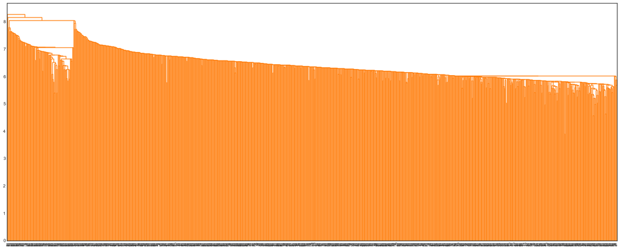

```python
Z = linkage(gene_df, 'single')
fig = plt.figure(figsize=(25,10))
dn = dendrogram(Z)
plt.show()
```

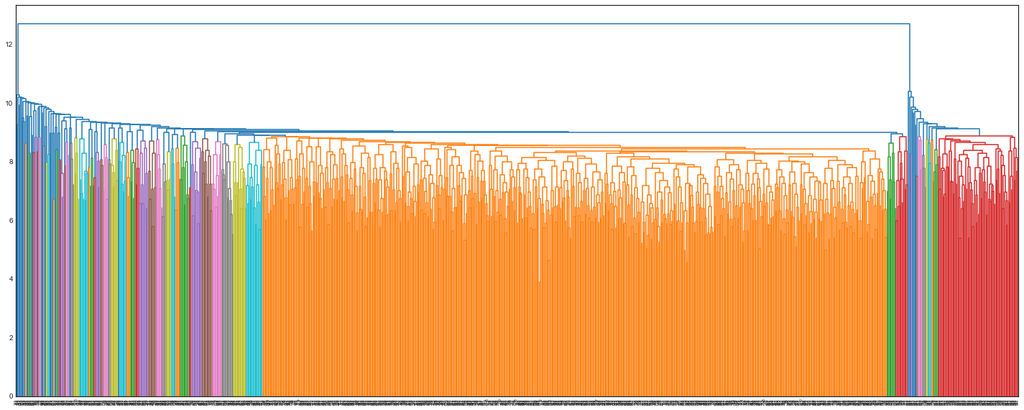

```python
Z2 = linkage(gene_df, 'average')
fig = plt.figure(figsize=(25,10))
dn = dendrogram(Z2)
plt.show()
```

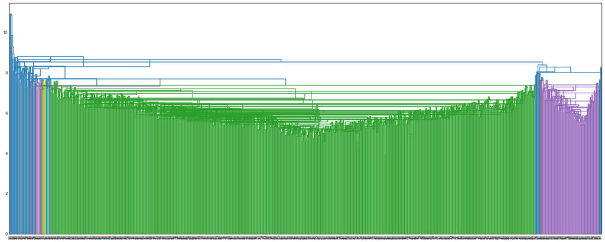

```python
Z3 = linkage(gene_df, 'median')
fig = plt.figure(figsize=(25,10))
dn = dendrogram(Z3)
plt.show()
```

These results are un-iterpretable, I will transpose the gene dataframe.

```python
gene_df2 = gene_df.T
# print(gene_df2.head())
```

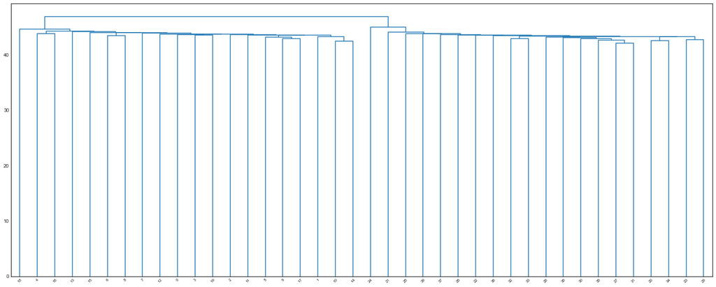

```python
Z = linkage(gene_df2, 'single')
fig = plt.figure(figsize=(25,10))
dn = dendrogram(Z)
plt.show()
```

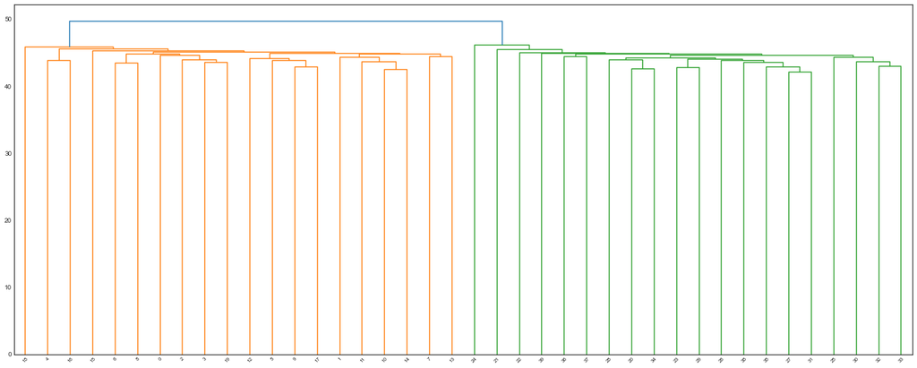

```python
Z2 = linkage(gene_df2, 'average')
fig = plt.figure(figsize=(25,10))
dn = dendrogram(Z2, color_threshold = 49)
plt.show()
```

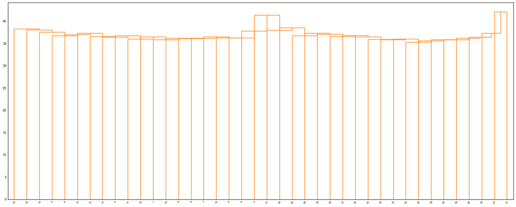

```python
Z3 = linkage(gene_df2, 'median')
fig = plt.figure(figsize=(25,10))
dn = dendrogram(Z3, color_threshold=49)
plt.show()
```

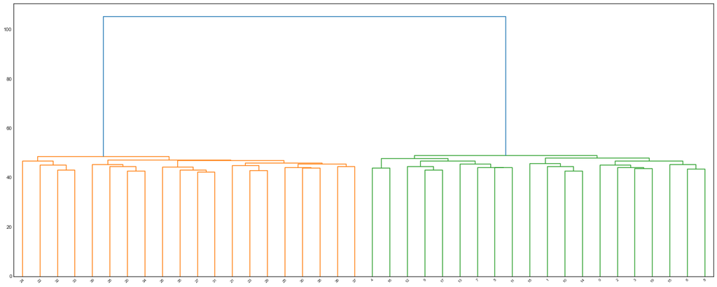

```python
Z4= linkage(gene_df2, 'ward')
fig = plt.figure(figsize=(25,10))
dn = dendrogram(Z4)
plt.show()
```

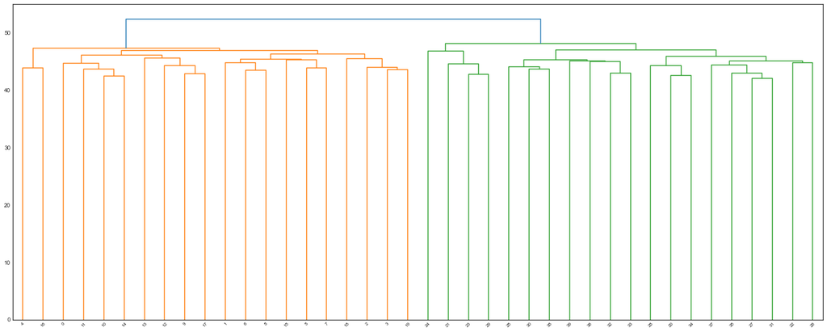

```python
Z5 = linkage(gene_df2, 'complete')
fig = plt.figure(figsize=(25,10))
dn = dendrogram(Z5,color_threshold=49)
plt.show()
```

It appears that most linkage methods do seperate the genes into two groups.

### (c) Your collaborator wants to know which genes differ the most across the two groups. Suggest a way to answer this question, and apply it here.

Perhaps we can implement principal component analysis.

```python
pca_gene = PCA(n_components=40)
principalComponents = pca_gene.fit(gene_df)
# df_pca_gene = pd.DataFrame(principalComponents, columns=['PC1', 'PC2'])
# df_pca['labels'] = gene_df2[[1000]]
# df_pca.labels = df_pca.labels.astype(int)
```

```python
print(principalComponents.explained_variance_ratio_)
```

```
[0.18699299 0.02998891 0.02842005 0.02751355 0.02714304 0.02649283
 0.02585679 0.0253583  0.02489026 0.02467986 0.02431694 0.02423387
 0.02355519 0.02297315 0.02263365 0.02243292 0.02177749 0.02151727
 0.02111598 0.02088552 0.02060847 0.02035784 0.01995302 0.01982156
 0.01934277 0.0188597  0.01867544 0.01805316 0.0178497  0.01766985
 0.0173848  0.01691103 0.01659561 0.01647373 0.01588294 0.01531126
 0.01525017 0.01461167 0.01382375 0.01378497]
```